# Generalized additive models for location, scale and shape: R Tutorial

December 2021

# Introduction

This is an R tutorial to accompany the paper:

*David Bann, Liam Wright, Tim J Cole. Risk factors relate to the variability of health outcomes as well as the mean: a GAMLSS tutorial. Elife, in press.*

If you find it useful, please cite it.

In this tutorial, we will demonstrate how to run and present *generalized additive models for location, scale and shape* (GAMLSS) in R. We also conduct quantile regression analysis for comparison purposes. To fully replicate the analysis in the paper, see https://www.osf.io/5tvz6.

# Preparing the Data and Loading Packages

We provide a small anonymised dataset provided in the file `df_tutorial.Rdata`.

```r
load("df_tutorial.Rdata")
summary(df_bcs)
```

```
##        id            bmi_46          sex
##  Min.   :    1   Min.   :15.24   Female:7833
##  1st Qu.: 4061   1st Qu.:24.55   Male  :8404
##  Median : 8121   Median :27.67   NA's  :   4
##  Mean   : 8121   Mean   :28.43
##  3rd Qu.:12181   3rd Qu.:31.46
##  Max.   :16241   Max.   :61.69
##                  NA's   :9584
```

In the tutorial, we will use the `tidyverse` package to prepare the dataset, the `quantreg` package to estimate quantile regressions, and the `gamlss` package to estimate GAMLSS models. We will load other packages as and when we need them.[^1]

```r
library(quantreg)
library(gamlss)
library(tidyverse)
```

Before starting the analysis, it is worth discussing the `tidyverse` in further detail.

## The `tidyverse`

The `tidyverse` is an “opinionated” package of packages that share a common design philosophy (https://www.tidyverse.org/). Popular tidyverse packages include `ggplot2`, `dplyr`, `tidyr`, `stringr` and `purrr`. Above you’ll see that the command `library(tidyverse)` loaded several packages. These are known as the “core” tidyverse packages. When installing the tidyverse, more packages are installed than the core packages (for instance, `broom` and `glue`), but these need to be loaded separately before use.

Because the tidyverse packages share a design philosophy, they work very well together (https://design.tidyverse.org/). Other developers can also create packages using the same philosophy, which means they can fit into the tidyverse ecosystem. This solves some of the coordination issues that can make using open-source software difficult.

Two central elements of the tidyverse are the use of “tidy” data and the `%>%` (“pipe”) operator. Tidy data are data in rectangular (data frame) format where each row is an observation and each column is a variable ([Wickham 2014](https://doi.org/10.18637/jss.v059.i10)). What is tidy can depend on context, but in general, *wide* data - where each row contains repeat observations from different timepoints - are not tidy, whereas *long* data - datasets with separate rows for each person time combination - are.

The pipe operator allows R users to chain functions together, piping the object on the left hand side to the first argument of the function on the right hand side. This makes code much easier to write and to read. Compare:

```r
paste(mean(1:10), "is the mean of 1 to 10.")
```

```
## [1] "5.5 is the mean of 1 to 10."
```

```r
1:10 %>%
  mean() %>%
  paste("is the mean of 1 to 10")
```

```
## [1] "5.5 is the mean of 1 to 10"
```

The pipe can be read sequentially (i.e. do this, then this, then this, …, etc). Users can also pipe objects into different arguments of a function using the “`.`” placeholder.[^2]

```r
paste("The mean of 1 to 10 is", mean(1:10))
```

```
## [1] "The mean of 1 to 10 is 5.5"
```

```r
1:10 %>%
  mean() %>%
  paste("The mean of 1 to 10 is", .)
```

```
## [1] "The mean of 1 to 10 is 5.5"
```

There are a lot of excellent tutorials on the `tidyverse` online. See, for instance, the [R for Data Science book](https://r4ds.had.co.nz/), the [R for Data Science Online Learning Community](https://www.rfordatasci.com/), and the [#rstats](https://twitter.com/hashtag/rstats) and [#tidytuesday](https://twitter.com/hashtag/tidytuesday) Twitter hashtags.

# Quantile Regression Analysis

Quantile regression models can be estimated using the `rq()` function from `quantreg`. The syntax is very similar to the `lm()` function used to estimate OLS models, with the exception that the quantile to be estimated also needs to be specified (`rq(tau = ...)`). Below, we produce a quantile regression model of BMI on sex at the 50th centile (i.e., the median).

```r
mod_1 <- rq(bmi_46 ~ sex, tau = 0.5, data = df_bcs)

summary(mod_1)
```

```
##
## Call: rq(formula = bmi_46 ~ sex, tau = 0.5, data = df_bcs)
##
## tau: [1] 0.5
##
## Coefficients:
##             Value     Std. Error t value   Pr(>|t|)
## (Intercept)  26.99956   0.12433  217.15209   0.00000
## sexMale       1.15287   0.15267    7.55141   0.00000
```

The `rq()` function can estimate regressions at different quantiles simultaneously by passing a vector to the `tau` argument. Below, we estimate quantile regression models at each quartile (25th, 50th, and 75th centiles).

```r
mod_2 <- rq(bmi_46 ~ sex, tau = c(0.25, 0.5, 0.75), data = df_bcs)

summary(mod_2)
```

```
##
## Call: rq(formula = bmi_46 ~ sex, tau = c(0.25, 0.5, 0.75), data = df_bcs)
##
## tau: [1] 0.25
##
## Coefficients:
##             Value     Std. Error t value   Pr(>|t|)
## (Intercept)  23.77071   0.08796  270.23643   0.00000
## sexMale       1.69209   0.12601   13.42792   0.00000
##
## Call: rq(formula = bmi_46 ~ sex, tau = c(0.25, 0.5, 0.75), data = df_bcs)
##
## tau: [1] 0.5
##
## Coefficients:
##             Value     Std. Error t value   Pr(>|t|)
## (Intercept)  26.99956   0.12433  217.15209   0.00000
## sexMale       1.15287   0.15267    7.55141   0.00000
##
## Call: rq(formula = bmi_46 ~ sex, tau = c(0.25, 0.5, 0.75), data = df_bcs)
##
## tau: [1] 0.75
##
## Coefficients:
##             Value     Std. Error t value   Pr(>|t|)
## (Intercept)  31.62130   0.16325  193.70365   0.00000
## sexMale      -0.29676   0.21145   -1.40348   0.16052
```

## Exporting and Plotting Quantile Regression Results

The `tbl_regression()` function from the package `gtsummary` can be used to present the results in a table.

```r
library(gtsummary)
tbl_regression(mod_1)
```

[output not shown]

<sup>*1*</sup> CI = Confidence Interval

The `gtsummary` package includes a vast array of options for formatting tables, including presenting the results from several regression models simultaneously. See the [package website](http://www.danieldsjoberg.com/gtsummary/) for more detail.

These results can also be plotted using the `ggplot2` package (part of the `tidyverse`). To extract model estimates from the `mod_2` object, we can use the `tidy()` function from the package `broom` (also part of the `tidyverse`). `tidy()` returns a data frame with model terms, coefficients, standard errors and/or confidence intervals, which makes model results simple to use with other `tidyverse` functions.

```r
library(broom)
tidy(mod_2, conf.int = TRUE)
```

```
## # A tibble: 6 × 5
##   term        estimate conf.low conf.high   tau
##   <chr>          <dbl>    <dbl>     <dbl> <dbl>
## 1 (Intercept)   23.8     23.6      23.9    0.25
## 2 sexMale        1.69     1.45      1.93   0.25
## 3 (Intercept)   27.0     26.7      27.2    0.5
## 4 sexMale        1.15     0.875     1.53   0.5
## 5 (Intercept)   31.6     31.3      31.9    0.75
## 6 sexMale       -0.297   -0.618     0.153  0.75
```

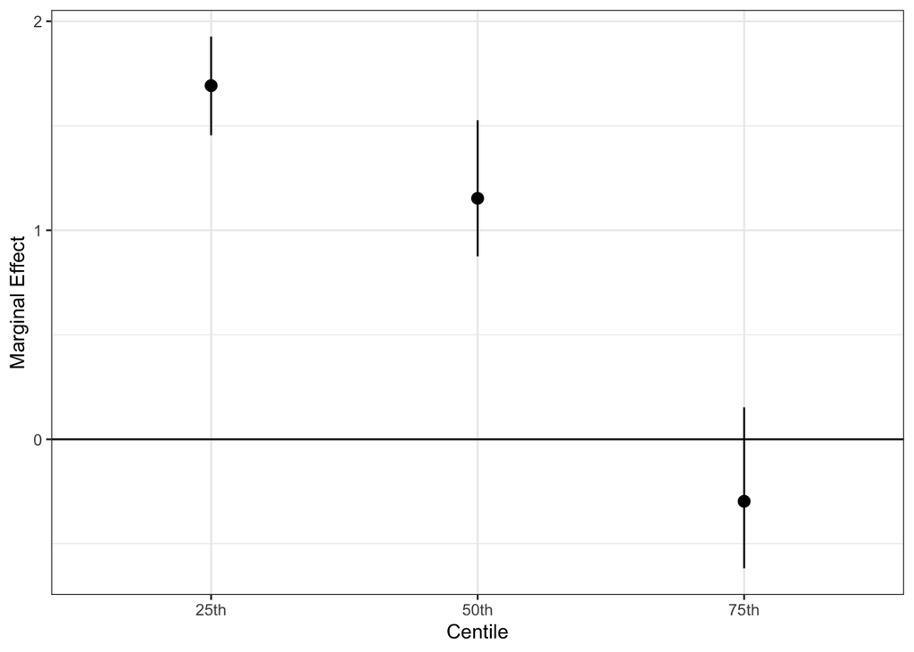

```r
tidy(mod_2, conf.int = TRUE) %>%
  filter(term == "sexMale") %>%
  mutate(centile = paste0(tau*100, "th")) %>%
  ggplot() +
  aes(x = centile, y = estimate, ymin = conf.low, ymax = conf.high) +
  geom_hline(yintercept = 0) +
  geom_pointrange() +
  theme_bw() +
  labs(x = "Centile", y = "Marginal Effect")
```

`ggplot2` syntax is a little confusing at first, but worth persevering with as it is extraordinarily powerful. `ggplot2` uses a concept called the *layered grammar of graphics*, which is a consistent way of describing plots. In the grammar of graphics, different types of plots (scatter plots, line graphs, density plots, etc.) are just specific instances of a general language. This means that when you understand the language, you can create different plots very simply. Compare this to creating plots in Stata, which requires knowledge of the idiosyncratic features of a particular plot.

The idea behind ggplot2 is as follows: `ggplot2` takes data, which are mapped to aesthetics (`aes()`; x-location, y-location, colour, shape, etc.). These aesthetics are represented visually with geometries (`geom_*()`). These geometries require a scale and (potentially) statistical transformations to be produced - for instance, bar plots require counts to be made from data. The geometries are projected onto a set of coordinates (Cartesian, polar, etc.) and finally non-data elements of the plot (title, axis labels, theme) can be adjusted with themes and other allied functions (e.g. `theme_bw()` and `labs()`). The layered aspect of ggplot2 is that plot elements (e.g., additional geometries) are added on top of the existing plot.

In the above plot, we took the data frame returned by `tidy()`, used `filter()` to keep rows where `term == sexMale`, and mapped the variable `centile` to a location on the x-axis, and `estimate`, `conf.low`, `conf.high` to the y-axis (the latter two as minima and maxima, respectively). Next we added a horizontal line passing through zero on the y-axis - this layer does not use the data returned from `tidy()` as we specified the `yintercept` argument separately. We then added a layer of `geom_pointrange()` which used the data mapped to the `x`, `y`, `ymin` and `ymax` aesthetics. `theme_bw()` and `labs()` prettified the plot.

To simplify the exposition, in what follows we won’t continue to prettify plots, but lots of information on producing elegant plots with `ggplot2` is available online (see, for instance, [the ggplot2 book](https://ggplot2-book.org/), [Gina Reynold’s ggplot2 flipbook](https://evamaerey.github.io/ggplot_flipbook/ggplot_flipbook_xaringan.html#1), and [Keiran Healy’s data visualisation textbook](https://socviz.co/)).

As an alternative to presenting model coefficients via `tidy()`, we can extract implied model predictions using the `predict()` function from `quantreg`. Passing a data frame of values to `predict()` returns a matrix of fitted values.

```r
tibble(sex = factor(c("Female", "Male"))) %>%
  predict(mod_2, .)
```

```
##   tau= 0.25 tau= 0.50 tau= 0.75
## 1  23.77071  26.99956  31.62130
## 2  25.46280  28.15244  31.32454
```

We’ll clean and save this before plotting the results with `ggplot()`.

```r
qreg_pred <- tibble(sex = factor(c("Female", "Male"))) %>%
  predict(mod_2, .) %>%
  as_tibble() %>%
  mutate(sex = c("Female", "Male"), .before = 1) %>% # Adds a column of sex values
  pivot_longer(-sex, names_to = ".tau", values_to = "bmi") %>% # Reshapes into long format
  mutate(tau = str_sub(.tau, -4, -1) %>% as.numeric(), # Converts the tau string to a number
         centile = tau * 100)

qreg_pred
```

```
## # A tibble: 6 × 5
##   sex    .tau        bmi   tau centile
##   <chr>  <chr>     <dbl> <dbl>   <dbl>
## 1 Female tau= 0.25  23.8  0.25      25
## 2 Female tau= 0.50  27.0  0.5       50
## 3 Female tau= 0.75  31.6  0.75      75
## 4 Male   tau= 0.25  25.5  0.25      25
## 5 Male   tau= 0.50  28.2  0.5       50
## 6 Male   tau= 0.75  31.3  0.75      75
```

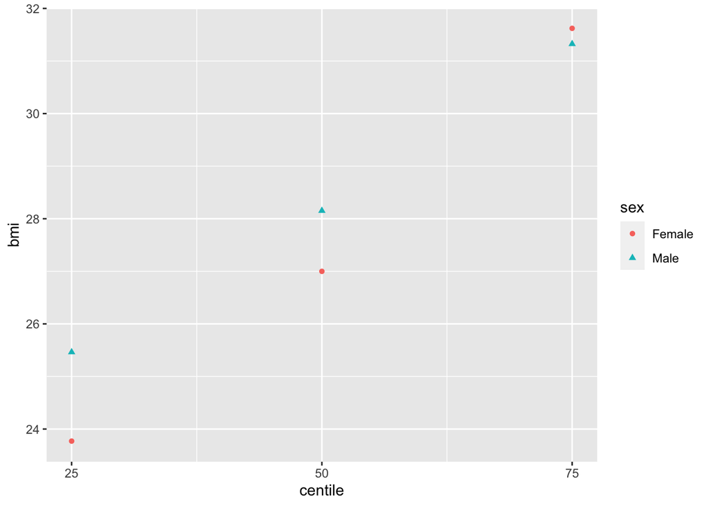

```r
ggplot(qreg_pred) +
  aes(x = centile, y = bmi, colour = sex, shape = sex) +
  geom_point() +
  scale_x_continuous(breaks = c(25, 50, 75))
```

In this plot, we passed `sex` to the `colour` and `shape` aesthetics, which means we produce a different coloured and shaped point for each sex.

# GAMLSS Analysis

GAMLSS models can be estimated using the `gamlss()` function from the `gamlss` package. The syntax is similar to that used in the `glm()` function to estimate generalised linear models in R. However, the main syntax differs from `glm()` in that formulae can be specified for multiple moments of the outcome distribution and a family needs to be specified using a `gamlss.family` object (see help `?gamlss.family` help files for example families).

The `gamlss()` function includes four arguments for specifying model parameter formulae: `formula`, `sigma.formula`, `nu.formula` and `tau.formula`. The parameters these formula correspond to depend on the family specified and each family does not necessarily use all formulae, but broadly they correspond to the first, second, third and fourth moments of the respective distribution, respectively (e.g. the mean or median, standard deviation or coefficient of variation, skewness, and kurtosis). Below, we estimate a GAMLSS model specifying a normal distribution family and modelling mean BMI (via `formula`) and its standard deviation as differing by sex (via `sigma.formula`). We specify a logarithmic link function for the mean, so that estimates reflect the percentage difference in mean BMI for males compared with females. (The standard deviation uses a logarithmic link function by default - see the help files, `?NO`.)

Note, for the code to run, the data frame passed to `gamlss()` must have no missing values in it. This can be achieved with the `drop_na()` function from the `tidyverse` (or the `na.omit()` function from base R). Note also that more covariates can be included in the model by adding these to the model formula (e.g. `bmi_46 ~ sex + father_class`).

```r
df_obs <- drop_na(df_bcs)

mod_3 <- gamlss(formula = bmi_46 ~ sex,
                sigma.formula = ~ sex,
                family = NO(mu.link = log),
                data = df_obs,
                trace = FALSE)

summary(mod_3)
```

```
## Family:  c("NO", "Normal")
##
## Call:  gamlss(formula = bmi_46 ~ sex, sigma.formula = ~sex,
##     family = NO(mu.link = log), data = df_obs, trace = FALSE)
##
## Fitting method: RS()
##
## ------------------------------------------------------------------
## Mu link function:  log
## Mu Coefficients:
##             Estimate Std. Error t value Pr(>|t|)
## (Intercept) 3.338890   0.003686 905.726  < 2e-16 ***
## sexMale     0.017752   0.004666   3.805 0.000143 ***
## ---
## Signif. codes:  0 '***' 0.001 '**' 0.01 '*' 0.05 '.' 0.1 ' ' 1
##
## ------------------------------------------------------------------
## Sigma link function:  log
## Sigma Coefficients:
##             Estimate Std. Error t value Pr(>|t|)
## (Intercept)  1.81088    0.01201  150.73   <2e-16 ***
## sexMale     -0.27684    0.01735  -15.96   <2e-16 ***
## ---
## Signif. codes:  0 '***' 0.001 '**' 0.01 '*' 0.05 '.' 0.1 ' ' 1
##
## ------------------------------------------------------------------
## No. of observations in the fit:  6657
## Degrees of Freedom for the fit:  4
##       Residual Deg. of Freedom:  6653
##                       at cycle:  2
##
## Global Deviance:     41233.94
##             AIC:     41241.94
##             SBC:     41269.15
```

The results show that both mean BMI and its variance differ by sex - mean have a 1.8% higher mean BMI than females (see Mu Coefficients) but a 27.7% smaller standard deviation (see Sigma Coefficients).

The code for running a GAMLSS model with a Box-Cox Cole and Green (BCCG) distribution is slightly different to the above. Below, we specify a BCCG GAMLSS model with median, coefficient of variation (CV; argument `sigma.formula`), and skewness (argument `nu.formula`) allowed to differ by sex. We use the `BCCGo` family object which uses a logarithmic link function for the median and the CV parameters and an identity link function for the skewness parameter. Estimates for the median and the CV therefore reflect percentage differences in these parameters for males compared with females.

```r
mod_4 <- gamlss(bmi_46 ~ sex,
                sigma.formula = ~ sex,
                nu.formula = ~ sex,
                family = BCCGo,
                data = df_obs,
                trace = FALSE)

summary(mod_4)
```

```
## Family:  c("BCCGo", "Box-Cox-Cole-Green-orig.")
##
## Call:  gamlss(formula = bmi_46 ~ sex, sigma.formula = ~sex,
##     nu.formula = ~sex, family = BCCGo, data = df_obs,      trace = FALSE)
##
## Fitting method: RS()
##
## ------------------------------------------------------------------
## Mu link function:  log
## Mu Coefficients:
##             Estimate Std. Error t value Pr(>|t|)
## (Intercept) 3.299843   0.003660  901.64   <2e-16 ***
## sexMale     0.039440   0.004723    8.35   <2e-16 ***
## ---
## Signif. codes:  0 '***' 0.001 '**' 0.01 '*' 0.05 '.' 0.1 ' ' 1
##
## ------------------------------------------------------------------
## Sigma link function:  log
## Sigma Coefficients:
##             Estimate Std. Error t value Pr(>|t|)
## (Intercept) -1.62013    0.01260 -128.57   <2e-16 ***
## sexMale     -0.23086    0.01781  -12.96   <2e-16 ***
## ---
## Signif. codes:  0 '***' 0.001 '**' 0.01 '*' 0.05 '.' 0.1 ' ' 1
##
## ------------------------------------------------------------------
## Nu link function:  identity
## Nu Coefficients:
##             Estimate Std. Error t value Pr(>|t|)
## (Intercept) -0.85155    0.07281 -11.695  < 2e-16 ***
## sexMale      0.46741    0.11433   4.088  4.4e-05 ***
## ---
## Signif. codes:  0 '***' 0.001 '**' 0.01 '*' 0.05 '.' 0.1 ' ' 1
##
## ------------------------------------------------------------------
## No. of observations in the fit:  6657
## Degrees of Freedom for the fit:  6
##       Residual Deg. of Freedom:  6651
##                       at cycle:  6
##
## Global Deviance:     40298.01
##             AIC:     40310.01
##             SBC:     40350.83
```

The results show that, modelling BMI as distributed with a BCCG distribution, the median, variance and skewness of BMI differ between males and females. Median BMI (Mu Cofficients) is higher among males, but the coefficient of variation (Sigma Coefficients) and skewness (Nu Coefficients) are lower. (In the present setting, a larger `nu` indicates lower skewness - see main paper.)

## Exporting and Plotting GAMLSS Results

The `tidy()` function can be used to extract model results, but in this case, the `broom.mixed` package is required.

```r
library(broom.mixed)
tidy(mod_4, conf.int = TRUE)
```

```
## # A tibble: 6 × 8
##   parameter term        estimate std.error statistic  p.value conf.low conf.high
##   <chr>     <chr>          <dbl>     <dbl>     <dbl>    <dbl>    <dbl>     <dbl>
## 1 mu        (Intercept)   3.30     0.00327   1009.   0          3.29      3.31
## 2 mu        sexMale       0.0394   0.00429      9.20 4.63e-20   0.0302    0.0487
## 3 sigma     (Intercept)  -1.62     0.0120    -135.   0         -1.63     -1.61
## 4 sigma     sexMale      -0.231    0.0173     -13.3  6.73e-40  -0.240    -0.222
## 5 nu        (Intercept)  -0.852    0.0649     -13.1  7.73e-39  -0.859    -0.844
## 6 nu        sexMale       0.467    0.107        4.37 1.29e- 5   0.458     0.477
```

Unfortunately, `tbl_regression()` cannot be used to create tables of GAMLSS results. Other packages, such as `texreg`, `modelsummary`, and `flextable`, are available, though are more involved than `gtsummary`. Describing these is beyond the scope of this tutorial.

If only the coefficients are required (and not their standard errors or confidence intervals), the `coef()` or `coefAll()` functions (from `gamlss`) can be used. `coefAll()` returns a list of named vectors containing model coefficients.

```r
coefs <- coefAll(mod_4)
coefs
```

```
## $mu
## (Intercept)     sexMale
##  3.29984337  0.03943975
##
## $sigma
## (Intercept)     sexMale
##  -1.6201258  -0.2308563
##
## $nu
## (Intercept)     sexMale
##  -0.8515508   0.4674052
```

We can use this to calculate BCCG distribution parameters for females (implied by the intercept terms) and males (implied by the sum of the intercept and `sexMale` terms), respectively, alongside the `map()` function from `purrr` (part of the `tidyverse`).

`map()` is an iterator function that can be used to repeat a function over a each element of an object. Below, we pass the `coefs` object to `map()`, along with the number `1`. This extracts the first element of each list element (`mu`, `sigma`, and `nu`) within `coefs`. Doing this, we can obtain the relevant BCCG distribution parameters for females (i.e. the model intercepts).

```r
coefs_female <- map(coefs, 1)
coefs_female
```

```
## $mu
## [1] 3.299843
##
## $sigma
## [1] -1.620126
##
## $nu
## [1] -0.8515508
```

For males, we instead need the summation of the model cofficients for each parameter, `mu`, `sigma`, and `nu`. We can calculate this by passing the `sum()` function to the second argument of `map()`. Passing a function `map()` applies that function to each element of the object inputted into the first argument, in turn.

```r
coefs_male <- map(coefs, sum)
coefs_male
```

```
## $mu
## [1] 3.339283
##
## $sigma
## [1] -1.850982
##
## $nu
## [1] -0.3841456
```

Next, we can use these parameters to calculate predicted BMI scores at each centile of the BCCG distribution. These can be derived using the following formula:

$$BMI = e^{mu} \cdot (1 + nu \cdot e^{sigma} \cdot \phi^{-1}(tau))^{1/nu}$$
where is $\phi^{-1}(x)$ is the Z-score at the 100x’th centile of the standard normal distribution.

Below, we create a new data frame containing the BCCG parameters for males and females, separately, using `bind_rows()` and `as_tibble()` functions from the `tidyverse`. `as_tibble()` creates a data frame from a list or vector and `bind_rows()` appends data frames together. We also use `uncount()` to expand the dataset so that there is one row by centile (1, 2, …, 99) and use the data to calculate fitted BMI values.

```r
gamlss_pred <- bind_rows(Female = as_tibble(coefs_female),
          Male = as_tibble(coefs_male),
          .id = "sex") %>%
  uncount(99, .id = "centile") %>%
  mutate(tau = centile/100,
         bmi = exp(mu) * (1 + nu * exp(sigma) * qnorm(tau))^(1/nu))

head(gamlss_pred)
```

```
## # A tibble: 6 × 7
##   sex       mu sigma     nu centile   tau   bmi
##   <chr>  <dbl> <dbl>  <dbl>   <int> <dbl> <dbl>
## 1 Female  3.30 -1.62 -0.852       1  0.01  18.4
## 2 Female  3.30 -1.62 -0.852       2  0.02  19.1
## 3 Female  3.30 -1.62 -0.852       3  0.03  19.6
## 4 Female  3.30 -1.62 -0.852       4  0.04  20.0
## 5 Female  3.30 -1.62 -0.852       5  0.05  20.3
## 6 Female  3.30 -1.62 -0.852       6  0.06  20.6
```

Next, we use `ggplot()` to display these results. We also include the quantile regression results for comparison. Note to do this, we include a `geom_point()` layer that inherits the aesthetic mappings specified from the `aes()` function but uses data from the `qreg_pred` dataframe instead.

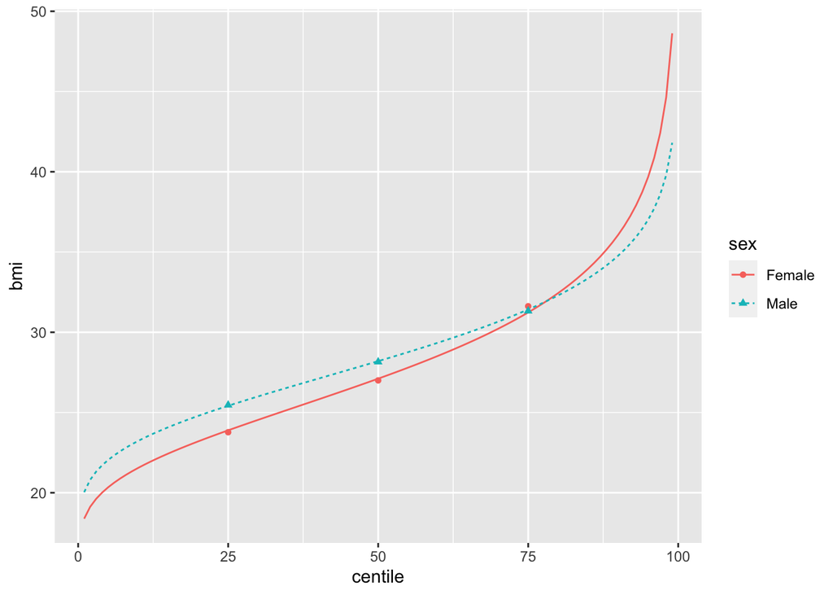

```r
ggplot(gamlss_pred) +
  aes(x = centile, y = bmi, colour = sex, linetype = sex, shape = sex) +
  geom_line() +
  geom_point(data = qreg_pred)
```

[^1]: Note, the order in which the packages are loaded is important here as `tidyverse` loads a function `select()` (from the package `dplyr`) that is different to the `select()` function loaded by `gamlss` (from the package `MASS`). Loading `tidyverse` after `gamlss` means `select()` loaded by the `tidyverse` will be called when used. However, a safer approach is to explicitly type `dplyr::select()` to ensure the correct function is used.
[^2]: R v 4.1 and above contain a native pipe operator (`|>`). Here we use the the tidyverse pipe for compatibility with earlier versions of R, and further as the native pipe has a less simple syntax for piping objects into different arguments of a function.